# code

```python
import pandas as pd
import numpy as np
from pyspark.sql import SparkSession
from pyspark.sql.functions import col, when, to_date, isnan, count, lit
from pyspark.ml.feature import VectorAssembler
import matplotlib.pyplot as plt
import seaborn as sns
```

```python
# Load the datasets
features = pd.read_csv("file:///mnt/c/Users/PMYLS/Downloads/142_sarim/Retail_data/Features_data_set.csv")
sales = pd.read_csv("file:///mnt/c/Users/PMYLS/Downloads/142_sarim/Retail_data/sales_data_set.csv")
stores = pd.read_csv("file:///mnt/c/Users/PMYLS/Downloads/142_sarim/Retail_data/stores_data_set.csv")

# Display the first few rows of each dataset
print("features:")
print(features.head())

print("\nsales:")
print(sales.head())

print("\nstores:")
print(stores.head())

# Data Preprocessing
# Convert 'Date' to datetime format
features['Date'] = pd.to_datetime(features['Date'], format='%d/%m/%Y')
sales['Date'] = pd.to_datetime(sales['Date'], format='%d/%m/%Y')

# Handle missing values
features.fillna(0, inplace=True)
```

```
features:
   Store        Date  Temperature  Fuel_Price  MarkDown1  MarkDown2  \
0      1  05/02/2010        42.31       2.572        NaN        NaN
1      1  12/02/2010        38.51       2.548        NaN        NaN
2      1  19/02/2010        39.93       2.514        NaN        NaN
3      1  26/02/2010        46.63       2.561        NaN        NaN
4      1  05/03/2010        46.50       2.625        NaN        NaN

   MarkDown3  MarkDown4  MarkDown5         CPI  Unemployment  IsHoliday
0        NaN        NaN        NaN  211.096358         8.106      False
1        NaN        NaN        NaN  211.242170         8.106       True
2        NaN        NaN        NaN  211.289143         8.106      False
3        NaN        NaN        NaN  211.319643         8.106      False
4        NaN        NaN        NaN  211.350143         8.106      False

sales:
   Store  Dept        Date  Weekly_Sales  IsHoliday
0      1     1  05/02/2010      24924.50      False
1      1     1  12/02/2010      46039.49       True
2      1     1  19/02/2010      41595.55      False
3      1     1  26/02/2010      19403.54      False
4      1     1  05/03/2010      21827.90      False

stores:
   Store Type    Size
0      1    A  151315
1      2    A  202307
2      3    B   37392
3      4    A  205863
4      5    B   34875
```

```python
# Display the info of the datasets to check for any other preprocessing steps
print("Features Data Info:\n", features.info())
print("Sales Data Info:\n", sales.info())
print("Stores Data Info:\n", stores.info())
```

```
<class 'pandas.core.frame.DataFrame'>
RangeIndex: 8190 entries, 0 to 8189
Data columns (total 12 columns):
 #   Column        Non-Null Count  Dtype
---  ------        --------------  -----
 0   Store         8190 non-null   int64
 1   Date          8190 non-null   datetime64[ns]
 2   Temperature   8190 non-null   float64
 3   Fuel_Price    8190 non-null   float64
 4   MarkDown1     8190 non-null   float64
 5   MarkDown2     8190 non-null   float64
 6   MarkDown3     8190 non-null   float64
 7   MarkDown4     8190 non-null   float64
 8   MarkDown5     8190 non-null   float64
 9   CPI           8190 non-null   float64
 10  Unemployment  8190 non-null   float64
 11  IsHoliday     8190 non-null   bool
dtypes: bool(1), datetime64[ns](1), float64(9), int64(1)
memory usage: 712.0 KB
Features Data Info:
 None
<class 'pandas.core.frame.DataFrame'>
RangeIndex: 421570 entries, 0 to 421569
Data columns (total 5 columns):
 #   Column        Non-Null Count   Dtype
---  ------        --------------   -----
 0   Store         421570 non-null  int64
 1   Dept          421570 non-null  int64
 2   Date          421570 non-null  datetime64[ns]
 3   Weekly_Sales  421570 non-null  float64
 4   IsHoliday     421570 non-null  bool
dtypes: bool(1), datetime64[ns](1), float64(1), int64(2)
memory usage: 13.3 MB
Sales Data Info:
 None
<class 'pandas.core.frame.DataFrame'>
RangeIndex: 45 entries, 0 to 44
Data columns (total 3 columns):
 #   Column  Non-Null Count  Dtype
---  ------  --------------  -----
 0   Store   45 non-null     int64
 1   Type    45 non-null     object
 2   Size    45 non-null     int64
dtypes: int64(2), object(1)
memory usage: 1.2+ KB
Stores Data Info:
 None
```

```python
import pandas as pd
# Merge the sales and features datasets on 'Store' and 'Date'
sales_features = pd.merge(sales, features, on=['Store', 'Date', 'IsHoliday'])

# Merge the resulting dataset with the stores dataset on 'Store'
integrated_data = pd.merge(sales_features, stores, on='Store')

# Display the first few rows of the integrated dataset
print("Integrated Data:\n", integrated_data.head())
# Write the integrated dataset to a CSV file
integrated_data.to_csv('integrated_data.csv', index=False)
```

```
Integrated Data:
    Store  Dept       Date  Weekly_Sales  IsHoliday  Temperature  Fuel_Price  \
0      1     1 2010-02-05      24924.50      False        42.31       2.572
1      1     1 2010-02-12      46039.49       True        38.51       2.548
2      1     1 2010-02-19      41595.55      False        39.93       2.514
3      1     1 2010-02-26      19403.54      False        46.63       2.561
4      1     1 2010-03-05      21827.90      False        46.50       2.625

   MarkDown1  MarkDown2  MarkDown3  MarkDown4  MarkDown5         CPI  \
0        0.0        0.0        0.0        0.0        0.0  211.096358
1        0.0        0.0        0.0        0.0        0.0  211.242170
2        0.0        0.0        0.0        0.0        0.0  211.289143
3        0.0        0.0        0.0        0.0        0.0  211.319643
4        0.0        0.0        0.0        0.0        0.0  211.350143

   Unemployment Type    Size
0         8.106    A  151315
1         8.106    A  151315
2         8.106    A  151315
3         8.106    A  151315
4         8.106    A  151315
```

**Hadoop Script**

**Providing necessary permissions**

chmod +x mapper.py

chmod +x reducer.py

chmod +x run_hadoop_job.sh

# !/bin/bash

**Define variables**

INPUT_FILE="/user/media/sales_data.csv"

HDFS_INPUT_DIR="/user/media"

HDFS_OUTPUT_DIR="/user/media/output"

MAPPER_SCRIPT="mapper.py"

REDUCER_SCRIPT="reducer.py"

**Upload scripts and data to HDFS**

hdfs dfs -put $INPUT_FILE $HDFS_INPUT_DIR/sales_data.csv

hdfs dfs -put $MAPPER_SCRIPT $HDFS_INPUT_DIR/$MAPPER_SCRIPT

hdfs dfs -put $REDUCER_SCRIPT $HDFS_INPUT_DIR/$REDUCER_SCRIPT

**Set executable permissions for the scripts**

hdfs dfs -chmod +x $HDFS_INPUT_DIR/$MAPPER_SCRIPT

hdfs dfs -chmod +x $HDFS_INPUT_DIR/$REDUCER_SCRIPT

**Run the Hadoop Streaming job**

hadoop jar /usr/lib/hadoop/hadoop-streaming.jar  
-input $HDFS_INPUT_DIR/sales_data.csv \ -output $HDFS_OUTPUT_DIR  
-mapper $HDFS_INPUT_DIR/$MAPPER_SCRIPT  
-reducer $HDFS_INPUT_DIR/$REDUCER_SCRIPT

**Retrieve the results**

hdfs dfs -cat $HDFS_OUTPUT_DIR/part-00000

**Running Script**

./run_hadoop_job.sh

```python
# Initialize Spark session
spark = SparkSession.builder.appName("AdvancedRetailDataAnalysis").getOrCreate()
```

```
24/06/20 22:52:04 WARN SparkSession: Using an existing Spark session; only runtime SQL configurations will take effect.
24/06/20 22:52:48 WARN TaskSetManager: Stage 0 contains a task of very large size (3867 KiB). The maximum recommended task size is 1000 KiB.
```

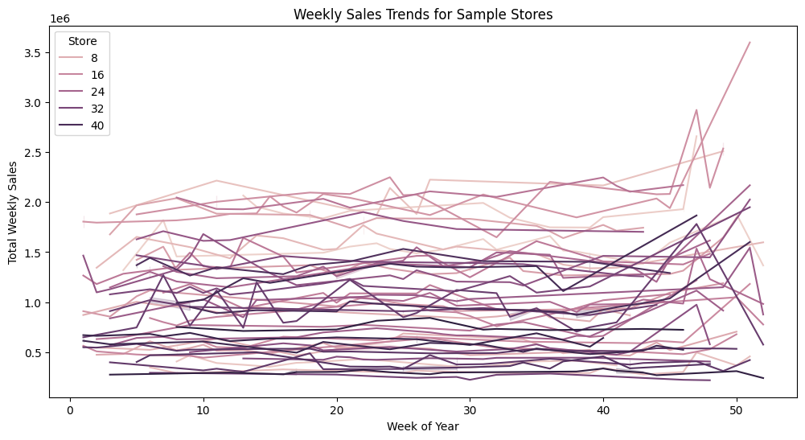

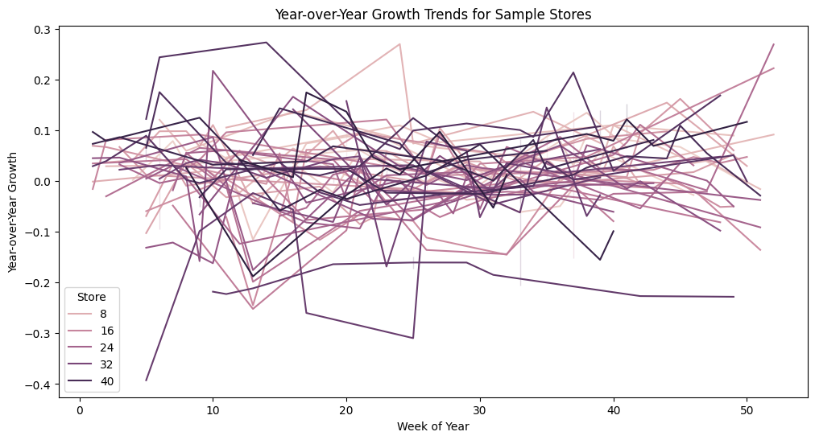

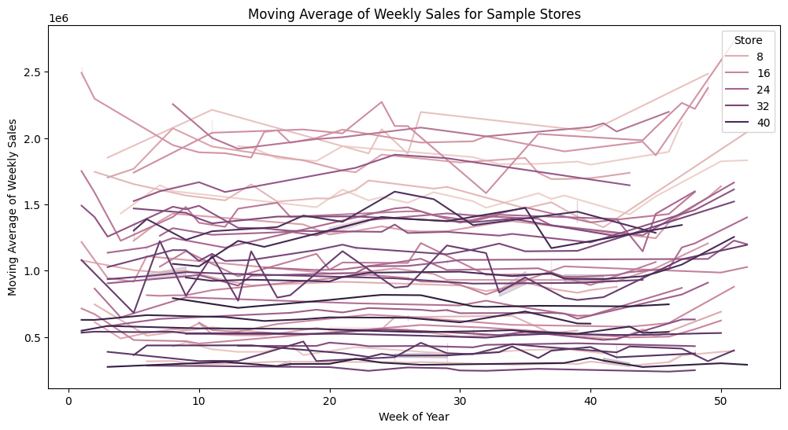

```python
from pyspark.sql import SparkSession
from pyspark.sql.functions import col, avg, weekofyear, year, sum as _sum, lag, when
from pyspark.sql.window import Window
import matplotlib.pyplot as plt
import seaborn as sns
from pyspark.ml.clustering import KMeans
from pyspark.ml.feature import VectorAssembler
from pyspark.sql import functions as F

# Initialize Spark session
spark = SparkSession.builder.appName("AdvancedRetailDataAnalysis").getOrCreate()

# Convert pandas dataframe to Spark dataframe
spark_df = spark.createDataFrame(integrated_data)

# Extract year and week of year from Date column
spark_df = spark_df.withColumn('Year', year('Date'))
spark_df = spark_df.withColumn('WeekOfYear', weekofyear('Date'))

# Calculate weekly sales per store
weekly_sales = spark_df.groupBy('Store', 'Year', 'WeekOfYear').agg(_sum('Weekly_Sales').alias('Total_Weekly_Sales'))

# Calculate year-over-year sales growth
window_spec = Window.partitionBy('Store', 'WeekOfYear').orderBy('Year')
weekly_sales = weekly_sales.withColumn('Prev_Year_Sales', lag('Total_Weekly_Sales').over(window_spec))
weekly_sales = weekly_sales.withColumn('YoY_Growth', when(col('Prev_Year_Sales').isNotNull(),(col('Total_Weekly_Sales') - col('Prev_Year_Sales')) / col('Prev_Year_Sales')).otherwise(None))

# Sales forecasting (simple moving average)
window_spec_avg = Window.partitionBy('Store').orderBy('Year', 'WeekOfYear').rowsBetween(-3, 0)
weekly_sales = weekly_sales.withColumn('Moving_Avg', avg('Total_Weekly_Sales').over(window_spec_avg))

# sample the data it's too large
weekly_sales_sampled = weekly_sales.sample(fraction=0.1, seed=42)

# Convert Spark dataframe to Pandas dataframe for visualization
weekly_sales_pd = weekly_sales_sampled.toPandas()

# Plot weekly sales trends for a sample of stores
plt.figure(figsize=(12, 6))
sns.lineplot(x='WeekOfYear', y='Total_Weekly_Sales', hue='Store', data=weekly_sales_pd)
plt.xlabel('Week of Year')
plt.ylabel('Total Weekly Sales')
plt.title('Weekly Sales Trends for Sample Stores')
plt.legend(title='Store')
plt.show()

# Plot year-over-year growth trends for a sample of stores
plt.figure(figsize=(12, 6))
sns.lineplot(x='WeekOfYear', y='YoY_Growth', hue='Store', data=weekly_sales_pd)
plt.xlabel('Week of Year')
plt.ylabel('Year-over-Year Growth')
plt.title('Year-over-Year Growth Trends for Sample Stores')
plt.legend(title='Store')
plt.show()

# Plot moving average of weekly sales for a sample of stores
plt.figure(figsize=(12, 6))
sns.lineplot(x='WeekOfYear', y='Moving_Avg', hue='Store', data=weekly_sales_pd)
plt.xlabel('Week of Year')
plt.ylabel('Moving Average of Weekly Sales')
plt.title('Moving Average of Weekly Sales for Sample Stores')
plt.legend(title='Store')
plt.show()

# Stop Spark session
spark.stop()
```

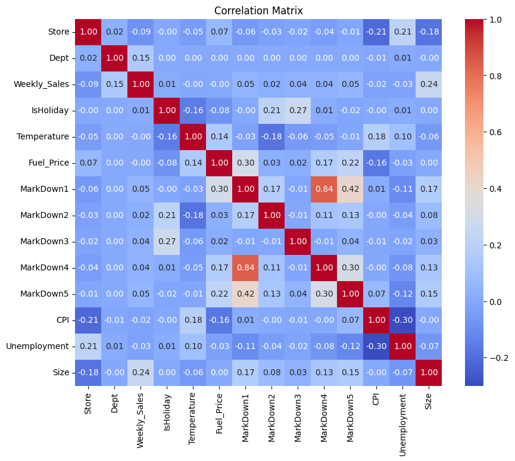

```python
import seaborn as sns
import matplotlib.pyplot as plt
import pandas as pd

# Convert 'IsHoliday' to numeric (0 for False, 1 for True)
integrated_data['IsHoliday'] = integrated_data['IsHoliday'].astype(int)

# Select only numeric columns for correlation matrix
numeric_cols = integrated_data.select_dtypes(include='number').columns
corr_matrix = integrated_data[numeric_cols].corr()

# Plot heatmap of correlation matrix
plt.figure(figsize=(10, 8))
sns.heatmap(corr_matrix, annot=True, cmap='coolwarm', fmt='.2f', square=True)
plt.title('Correlation Matrix')
plt.show()
```

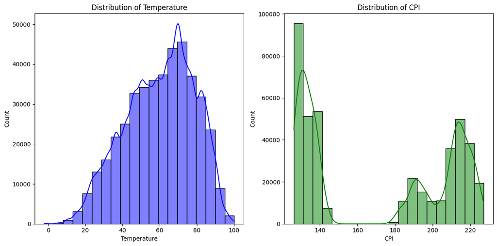

```python
# Plot distributions of Temperature and CPI
plt.figure(figsize=(12, 6))
plt.subplot(1, 2, 1)
sns.histplot(integrated_data['Temperature'], bins=20, kde=True, color='blue')
plt.xlabel('Temperature')
plt.title('Distribution of Temperature')

plt.subplot(1, 2, 2)
sns.histplot(integrated_data['CPI'], bins=20, kde=True, color='green')
plt.xlabel('CPI')
plt.title('Distribution of CPI')

plt.tight_layout()
plt.show()
```

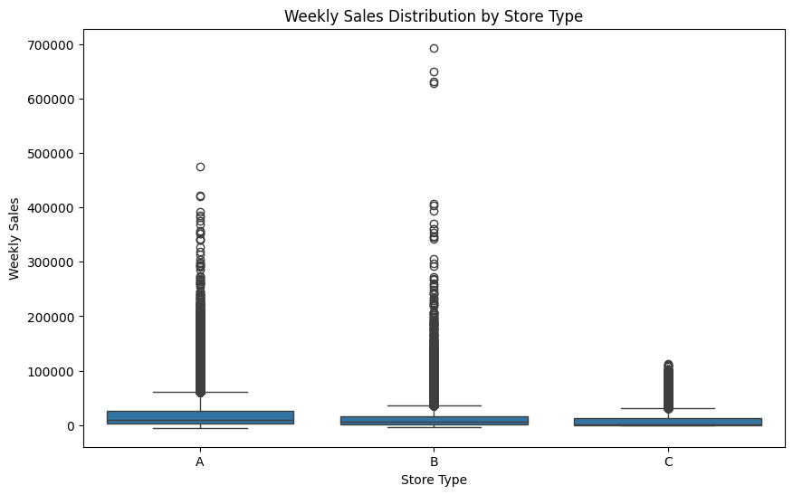

```python
# Plot sales analysis by store type
plt.figure(figsize=(10, 6))
sns.boxplot(x='Type', y='Weekly_Sales', data=integrated_data)
plt.xlabel('Store Type')
plt.ylabel('Weekly Sales')
plt.title('Weekly Sales Distribution by Store Type')
plt.show()
```